# Table of Contents

## Read before you start

- Hand in the notebook to Brightspace named as follows: `StudentName1_snumber_StudentName2_snumber.ipynb`.
- Provide clear and complete answers to the questions below within the horizontal rules, and make sure to explain your answers / motivate your choices. Add Markdown or code cells where necessary.
- Code, output graphs, derivations, etc., should be included in the notebook.
- Use the Brightspace discussion board for questions on how to complete the exercises.

```python
import matplotlib.pyplot as plt

plt.style.use('ggplot')
plt.rc('font', size=14)         # default fontsize
plt.rc('axes', titlesize=16)    # fontsize of the axes title
plt.rc('axes', labelsize=16)    # fontsize of the x and y labels
plt.rc('xtick', labelsize=14)   # fontsize of the tick labels
plt.rc('ytick', labelsize=14)   # fontsize of the tick labels
plt.rc('legend', fontsize=16)   # legend fontsize
plt.rc('figure', titlesize=16)  # fontsize of the figure title
plt.rc('figure', titlesize=16)  # fontsize of the figure title
```

# Bayesian Statistics: Exercises for week 02

## Incrementally updating your beliefs

**2 pt(s)**

Suppose that the fictional president of a fictional country is acting weird and he might be impeached. Someone made a scrappy poll using Google Survey, and found that of the 100 semi-randomly sampled participants, 61 were in favor of impeachment and the rest was against.

1. Suppose you had never heard of this president before (i.e. you had a uniform prior belief about the impeachment). What is the 95\% HDI after learning about the poll? Use the function `bernbeta_post` imported from `utilities.py`. Note: what probabilistic model (i.e. which probability distribution or combination of distributions) do you need for this problem?

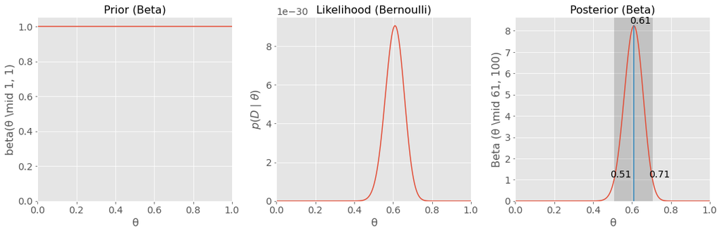

```python
from utilities import bernbeta_post
#param_prior, param_likelihood =
a = 1
b = 1
z = 61
N = 100
a2,b2 = bernbeta_post((a,b),(z,N))
```

*Your answer here.*

</span>

the 95% HDI is between 0.51 and 0.71.

1. You collect additional data to obtain a more accurate estimate of the population's preference, and find that in an additional 100 semi-randomly sampled people, 67 are in favor and the rest is against. How does this update your 95\% HDI?

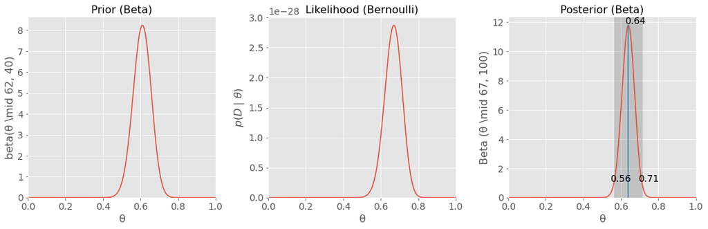

```python
z = 67
N = 100
a3, b3 = bernbeta_post((a2,b2),(z,N))
```

*Your answer here.*

</span>

The 95% HDI is after update between 0.56 and 0.71, the lowerbound and the mean are shifted towards the right.

1. On your travels you encounter a population with very different political views. After your two previous polls, you now find that only 7 out of 100 newly sampled participants are in favor of impeachment. How does this inconsistent result change your HDI?

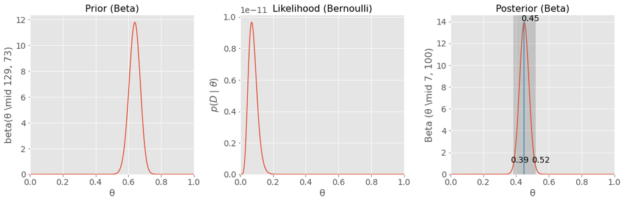

```
(136, 166)
```

```python
z = 7
N = 100
bernbeta_post((a3,b3),(z,N))
```

*Your answer here.*

</span>

It does change a lot, the HDI is shifted towards the left, all boundaries do have a lower value than before.

## Small, but realistic application in a behavioural experiment

**2 pts(s)**

You have set up the following experiment to study a learning task. You present people the two words 'tree' and 'cat' simultaneously, and instruct your subjects to press 'F' when they see this word combination (mixed with other words and combinations for which they should not respond). You then introduce another relevant word combination, 'tree' and 'dog', which should be followed by pressing 'J'. Your subjects keep training until they have learned this task well. Now you provide them with two novel scenarios. In the first, you just show them the word 'tree' by itself, and instruct them to make the best response (F or J), based on what they have learned earlier. Next, you show them the words 'cat' and 'dog' and ask again for the best response.

After conducting your experiment, you have the following data:

- For the single-word probe, 35 people chose F and 15 chose J.
- For the combination of 'cat' and 'dog', 13 chose F and 37 chose J.

Your (research) question is: are people biased towards either F or J for either of the two probes? In other words, do people make a systematic choice in generalizing to the new setting, or do they pick something at random?

1. Find the answer to this research question. You may assume a uniform distribution as your prior, and you have to use the 95% highest density interval to base your conclusion on (see chapter 12 if you need a hint, but you can probably do without).

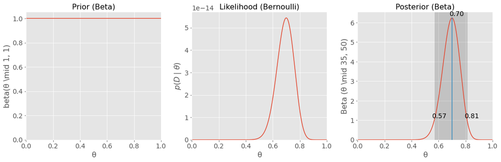

```python
# "tree":
a = 1
b = 1
z = 35
N = 50
a4,b4 = bernbeta_post((a,b),(z,N))
```

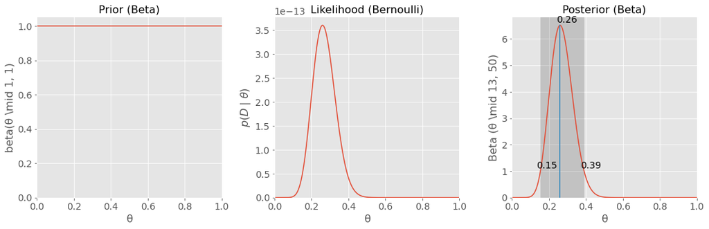

```
(14, 38)
```

```python
# "cat and dog":
a = 1
b = 1
z = 13
N = 50
bernbeta_post((a,b),(z,N))
```

*Your answer here.*

</span>

In the first posterior plot, we can see a preference towards the right side, so people are biased towards F

In the second posterior plot, we can see preference towards the left side, so people are biased towards J

So the answer to the research question: People are biased towards either F or J for either of the two probes, people make a systematic choice in generalizing to the new setting.

1. Suppose that for an earlier experiment, the combination of 'cat' and 'dog' resulted in 20 F and 5 J. Does this change your conclusion to the second experiment?

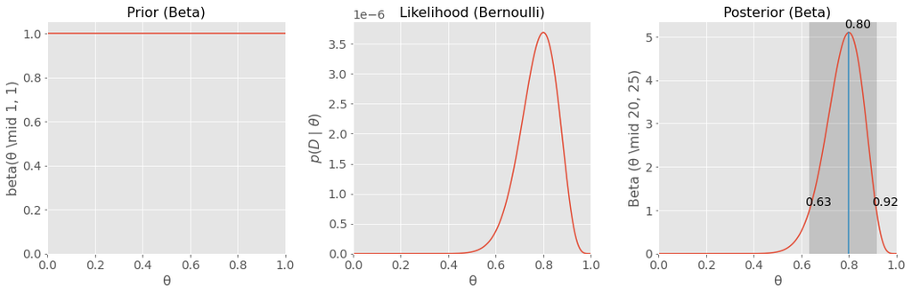

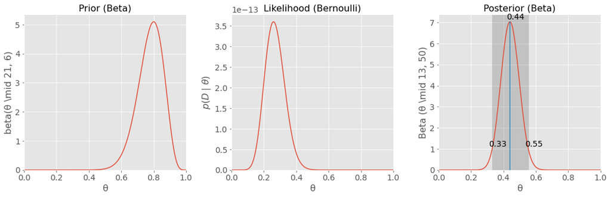

```
(34, 43)
```

```python
a = 1
b = 1
z = 20
N = 25
a5,b5 = bernbeta_post((a,b),(z,N))

z1 = 13
N2 = 50
bernbeta_post((a5,b5),(z1,N2))
```

*Your answer here.*

</span>

Yes it does change my conclusion to the second experiment. The values shifted towards the middle(0.5), which means that it will be more random and not biased towards either F or J.

## Difficulties with Bayesian inference

**3 pt(s)**

Many realistic problems study not a single parameter, but a whole bunch of them. For example, one might be interested in networks. A network consists of *nodes*, that can represent people, proteins, brain regions, traffic junctions, etc., and *edges*, that represent the interactions between nodes. Note that there are many more connections than nodes!

The presence of an interaction between two nodes can again be represented by a Bernoulli variable – the connection is either present or absent. Typically, the individual connections are assumed to be independent *a priori*. This makes it easier to define a prior over the entire network $A=\{a\}_{ij}$ as the product of the individual connections

$$ p(A\mid \theta) = \prod_{i\neq j} p(a_{ij}\mid \theta) \enspace, $$

where $p(a_{ij}\mid \theta)$ is the familiar Bernoulli likelihood. The difficulty in computing the posterior of a network, i.e. $p(A\mid x,\theta)$, where $x$ are observations, is that if the posterior does not have a closed form solution, the sum in marginal likelihood

$$ p(x\mid \theta) = \sum_{A} p(x\mid A) p(A \mid \theta) $$

can be over many terms; too many to realistically compute.

Assume the network $A$ contains no self-loops (i.e. $a_{ii}=0$ for all $i$), and assume the networks are directed (that is $a_{ij}$ is another connection than $a_{ji}$).

1. Under what condition is the posterior $p(A\mid x,\theta)$ *not* in closed form?

*Your answer here.*

</span>

This is the case when the prior is not a conjugate, so when the prior and posterior do not look the same, which means it is difficult to solve the integral with calculus(not closed).

1. Over how many *different* networks does the equation above sum if the networks contain 10 nodes?

*Your answer here.*

</span>

10 nodes, every node has 9 edges. Summed up over every node results in 90 edges, which can be present of absent thus 2^90. This is 1.237940039285380274899124224 × 10^27

1. What about a network of 100 nodes?

Note that these numbers are the number of terms in the sum of the equation above. Not even a modern supercomputer can handle such numbers. (Hint: Python can't even *show* these numbers, but try [Wolfram Alpha](http://www.wolframalpha.com) instead.)

*Your answer here.*

</span>

100 nodes, every node has 99 edges. Summed up over every node results in 99 *100 edges, which can be present of absent thus 2^(99* 100) = 1.573827296355608337957894017415189031101493441839186506469 × 10^2980

1. What would happen if you just skipped the marginal likelihood altogether, i.e. you would compute

   \begin{equation}

   ```
    p(A\mid x,\theta) \propto p(x\mid A,\theta) p (A\mid \theta) \enspace.
   ```

   \end{equation}

   Which property of a probability distribution is now lost? Can you think of an application where unnormalized distribution is still useful? Think about what property of the distribution is still there.

*Your answer here.*

</span>

The property of normalization is lost, the total sum of the distribution is not 1 anymore. Unnormalized distributions are useful to describe a data distribution. It is easier and more meaningful to model the shape of the data distribution. The properties that are intact are the domain (theta) is still between 0 and 1 and the shape. An application where it is still useful is in neural probabilistic language models, this can be used for machine translation, sentence completion, or speech recognition

## Conjugate priors

**3 pt(s)**

When you have a likelihood such as the Bernoulli distribution, i.e. $p(z,N\mid \theta)$, as well as a conjugate prior such as the beta distribution, $p(\theta\mid a,b)$, we might not care about $\theta$ if we only want to model the data adequately (instead of wanting to *infer* $\theta$). In that case, we can also define

\begin{equation} p(z,N\mid a,b) = \int_0^1 \! \, \overbrace{p(z,N\mid \theta)}^{\mathrm{likelihood}} \underbrace{p(\theta\mid a,b)}_{\mathrm{prior}} \,\mathrm{d}\theta \enspace, \end{equation}

i.e. we have *integrated out* (or *marginalized out*) the parameter $\theta$. This means we do not care about $\theta$, but we let the data depend directly on our pseudo counts.

Now integrals can be difficult compute, but *being clever* goes a long way.

1. Prove that \begin{equation} p(z,N\mid a,b) = \frac{B(z+a, N-z+b)}{B(a,b)} \end{equation}.

Note: if you are using a lot of calculus to get to the result, you are doing it wrong! You only have to expand the formulae for prior and likelihood and look carefully at their formulas.

*Your answer here.*

</span>

\begin{equation} p(z,N\mid a,b) = \int_0^1 \! \, \overbrace{p(z,N\mid \theta)}^{\mathrm{likelihood}} \underbrace{p(\theta\mid a,b)}_{\mathrm{prior}} \,\mathrm{d}\theta \enspace, \end{equation}

\begin{equation} p(z, N) = {\theta^{z}(1-\theta)^{N-z}} \end{equation}

.

\begin{equation} p(\theta\mid a,b) = {\theta^{a-1}(1-\theta)^{b-1} \frac{1}{B(a,b)}} \end{equation}

.

\begin{equation} p(z,N\mid a,b) = \int_0^1 \! \,{\theta^{z}(1-\theta)^{N-z}}{\theta^{a-1}(1-\theta)^{b-1} \frac{1}{B(a,b)}}\mathrm{d}\theta \end{equation}

.

\begin{equation} p(z,N\mid a,b) = \frac{1}{B(a,b)}\int_0^1 \! \,{\theta^{z}(1-\theta)^{N-z}}{\theta^{a-1}(1-\theta)^{b-1}}\mathrm{d}\theta \end{equation}

.

\begin{equation} p(z,N\mid a,b) = \frac{1}{B(a,b)}\int_0^1 \! \,{\theta^{z+a-1}(1-\theta)^{N-z+b-1}}\mathrm{d}\theta \end{equation}

.

\begin{equation} B(a,b) = \int_0^1 \! \,{\theta^{a-1}(1-\theta)^{b-1}}\mathrm{d}\theta \end{equation}

.

\begin{equation} B(a+z,N-z+b) = \int_0^1 \! \,{\theta^{a+z-1}(1-\theta)^{N-z+b-1}}\mathrm{d}\theta \end{equation}

.

\begin{equation} p(z,N\mid a,b) = \frac{1}{B(a,b)}B(a+z,N-z+b) \end{equation}

.

\begin{equation} p(z,N\mid a,b) = \frac{B(z+a, N-z+b)}{B(a,b)} \end{equation}

.